# Assignment 5

Dominique Mashini

03-10-2020

# Assignment 5: Comparing Regression Models

For this assignment, I will use the following libraries:

```r
library(tidyverse)
library(tidycensus)
library(jtools)
library(interactions)
library(knitr)
```

## Defining, combining, and renaming variables

I obtained the data from the 1-year ACS Public Use survey at the person-level in the state of Texas (year 2018). After browsing through the database, I defined and renamed my 5 variables of interest:

1. Travel time to work (var code: **JWMNP**) = Traveltime (continuous)
2. Age (var code: **AGEP**) = Age (continuous)
3. Educational attainment (var code: **SCHL**) = Edattain (categorical)
4. Means of Transportation (var code: **JWTR**) = Meanstransp (categorical)
5. Total person’s income (var code: **PINCP**) = Income (continuous)

I filtered the data, eliminating the observations with 0 and negative values in the income and travel time variables. I also selected my variables of interest for my categorical variables. I merged some sub-categories of means of transportation, because it is interesting to analyze active mobility (bicycle or walked), public transportation (bus, streetcar, or subway), and private transportation (car, truck, or van).

For this assignment I added the sex variable (var code: **SEX**) because I think it will make a difference for my model fit.

```r
vars <- c(
  Traveltime = "JWMNP",
  Age = "AGEP",
  Edattain = "SCHL",
  Meanstransp = "JWTR",
  Income = "PINCP",
  Sex = "SEX"

)

data <- get_pums(
  variables = vars,
  state = "TX",
  year = 2018,
  survey = "acs1",
  recode = TRUE
) %>%
    filter(Traveltime > 1) %>%
  filter(Income > 0) %>%
  filter(Meanstransp == "01"| Meanstransp == "02"| Meanstransp == "03"|Meanstransp == "04"|Meanstransp == "09"|Meanstransp == "10") %>%
  filter(Edattain == "01"| Edattain == "16" | Edattain == "19" | Edattain == "21" | Edattain == "22" | Edattain == "24") %>%
mutate(Meanstransp = case_when(
    Meanstransp == "01" ~ "1 Car, truck, or van",
    Meanstransp == "03" | Meanstransp == "04"  | Meanstransp == "02" ~ "2 Bus, streetcar or subway",
    Meanstransp == "09" | Meanstransp == "10" ~ "3 Bicycle or walked")) %>%

  mutate(Edattain = case_when(
    Edattain == "01" ~ "1 No schooling completed",
    Edattain == "16" ~ "2 Highschool diploma",
    Edattain == "19" ~ "3 College credit",
    Edattain == "21" ~ "4 Bachelor",
    Edattain == "22" ~ "5 Masters",
    Edattain == "24" ~ "6 Doctorate"))
```

## Initial regression model

First, I ran the linear regression model I used for my last assignment predicting travel time to work, based on income, age, educational attainment, and means of transportation.

```r
model1 <- lm(Traveltime ~ Income + Age + Edattain + Meanstransp,
            data = data)
options(scipen = 999)

summary(model1)
```

```
##
## Call:
## lm(formula = Traveltime ~ Income + Age + Edattain + Meanstransp,
##     data = data)
##
## Residuals:
##     Min      1Q  Median      3Q     Max
## -45.671 -12.853  -5.612   5.082 148.778
##
## Coefficients:
##                                            Estimate    Std. Error t value
## (Intercept)                            25.460190516   0.603923698  42.158
## Income                                  0.000019300   0.000001142  16.901
## Age                                     0.035967871   0.005562536   6.466
## Edattain2 Highschool diploma           -1.490592965   0.563658489  -2.644
## Edattain3 College credit               -1.604802451   0.568751697  -2.822
## Edattain4 Bachelor                     -1.930538612   0.564117466  -3.422
## Edattain5 Masters                      -1.949623452   0.590077587  -3.304
## Edattain6 Doctorate                    -3.929065787   0.773228243  -5.081
## Meanstransp2 Bus, streetcar or subway  20.662277128   0.709083653  29.139
## Meanstransp3 Bicycle or walked        -12.322605795   0.565035930 -21.809
##                                                   Pr(>|t|)
## (Intercept)                           < 0.0000000000000002 ***
## Income                                < 0.0000000000000002 ***
## Age                                         0.000000000101 ***
## Edattain2 Highschool diploma                      0.008183 **
## Edattain3 College credit                          0.004779 **
## Edattain4 Bachelor                                0.000621 ***
## Edattain5 Masters                                 0.000954 ***
## Edattain6 Doctorate                         0.000000375571 ***
## Meanstransp2 Bus, streetcar or subway < 0.0000000000000002 ***
## Meanstransp3 Bicycle or walked        < 0.0000000000000002 ***
## ---
## Signif. codes:  0 '***' 0.001 '**' 0.01 '*' 0.05 '.' 0.1 ' ' 1
##
## Residual standard error: 21.65 on 77697 degrees of freedom
## Multiple R-squared:  0.02268,    Adjusted R-squared:  0.02257
## F-statistic: 200.4 on 9 and 77697 DF,  p-value: < 0.00000000000000022
```

In my last assignment I recognized that this model predicts about 2% of the variation in time travel (minutes) from my data set (with a 0.023 R-squared value). I considered it a low value, because it is difficult to predict and explain travel time through my independent variables: age, means of transportation, income, and educational attainment. After looking at my p-values, I found that the coefficients were statistically significant at a 95-percentage confidence interval.

## Regression model with a log transformation

Considering that the differences in travel time for each additional dollar earned by a person is a more substantial increase with lower income than with higher income, I decided to apply a log transformation to this variable.

```r
model2 <- lm(Traveltime ~ log(Income) + Age + Edattain + Meanstransp,
            data = data)
options(scipen = 999)

summary(model2)
```

```
##
## Call:
## lm(formula = Traveltime ~ log(Income) + Age + Edattain + Meanstransp,
##     data = data)
##
## Residuals:
##     Min      1Q  Median      3Q     Max
## -46.650 -13.044  -5.423   6.291 157.810
##
## Coefficients:
##                                           Estimate   Std. Error t value
## (Intercept)                             1.37525254   0.96760914   1.421
## log(Income)                             2.62789194   0.08391627  31.316
## Age                                    -0.00005821   0.00569743  -0.010
## Edattain2 Highschool diploma           -1.93595661   0.56141429  -3.448
## Edattain3 College credit               -2.26879552   0.56677393  -4.003
## Edattain4 Bachelor                     -3.41159146   0.56413818  -6.047
## Edattain5 Masters                      -3.68681767   0.59054179  -6.243
## Edattain6 Doctorate                    -5.67108475   0.77069110  -7.358
## Meanstransp2 Bus, streetcar or subway  21.36536997   0.70641995  30.245
## Meanstransp3 Bicycle or walked        -10.90458846   0.56487958 -19.304
##                                                   Pr(>|t|)
## (Intercept)                                       0.155237
## log(Income)                           < 0.0000000000000002 ***
## Age                                               0.991848
## Edattain2 Highschool diploma                      0.000564 ***
## Edattain3 College credit                 0.000062602555733 ***
## Edattain4 Bachelor                       0.000000001478348 ***
## Edattain5 Masters                        0.000000000431162 ***
## Edattain6 Doctorate                      0.000000000000188 ***
## Meanstransp2 Bus, streetcar or subway < 0.0000000000000002 ***
## Meanstransp3 Bicycle or walked        < 0.0000000000000002 ***
## ---
## Signif. codes:  0 '***' 0.001 '**' 0.01 '*' 0.05 '.' 0.1 ' ' 1
##
## Residual standard error: 21.55 on 77697 degrees of freedom
## Multiple R-squared:  0.03132,    Adjusted R-squared:  0.03121
## F-statistic: 279.1 on 9 and 77697 DF,  p-value: < 0.00000000000000022
```

## Regression model converting a continuous variable to a categorical variable

Based on my previous model, I decided to transform my age variable into a categorical one. The main reason I think it will make a difference is that age is probably related to commuting times, but with different variations according to age ranges.

Then, I apply the regression model with age as a categorical variable:

```r
datacat <- data %>%
  mutate(Agecat = case_when(Age < 20  ~ "1 Under 20yrs",
                               Age >= 20 & Age < 65 ~ "2 Over20 Under65",
                               Age >= 65 ~ "3 Over 65"))
model3 <- lm(Traveltime ~ log(Income) + Agecat + Edattain + Meanstransp,
            data = datacat)

summary(model3)
```

```
##
## Call:
## lm(formula = Traveltime ~ log(Income) + Agecat + Edattain + Meanstransp,
##     data = datacat)
##
## Residuals:
##     Min      1Q  Median      3Q     Max
## -46.830 -13.044  -5.344   6.356 160.389
##
## Coefficients:
##                                        Estimate Std. Error t value
## (Intercept)                            -0.92002    1.02322  -0.899
## log(Income)                             2.55491    0.08217  31.093
## Agecat2 Over20 Under65                  3.27574    0.53717   6.098
## Agecat3 Over 65                         0.86895    0.61530   1.412
## Edattain2 Highschool diploma           -1.85091    0.56028  -3.304
## Edattain3 College credit               -2.24290    0.56456  -3.973
## Edattain4 Bachelor                     -3.44545    0.56176  -6.133
## Edattain5 Masters                      -3.66826    0.58884  -6.230
## Edattain6 Doctorate                    -5.48254    0.76981  -7.122
## Meanstransp2 Bus, streetcar or subway  21.25218    0.70609  30.098
## Meanstransp3 Bicycle or walked        -10.79822    0.56460 -19.126
##                                                   Pr(>|t|)
## (Intercept)                                       0.368582
## log(Income)                           < 0.0000000000000002 ***
## Agecat2 Over20 Under65                    0.00000000107778 ***
## Agecat3 Over 65                                   0.157881
## Edattain2 Highschool diploma                      0.000955 ***
## Edattain3 College credit                  0.00007108520901 ***
## Edattain4 Bachelor                        0.00000000086492 ***
## Edattain5 Masters                         0.00000000046985 ***
## Edattain6 Doctorate                       0.00000000000107 ***
## Meanstransp2 Bus, streetcar or subway < 0.0000000000000002 ***
## Meanstransp3 Bicycle or walked        < 0.0000000000000002 ***
## ---
## Signif. codes:  0 '***' 0.001 '**' 0.01 '*' 0.05 '.' 0.1 ' ' 1
##
## Residual standard error: 21.54 on 77696 degrees of freedom
## Multiple R-squared:  0.03251,    Adjusted R-squared:  0.03238
## F-statistic: 261.1 on 10 and 77696 DF,  p-value: < 0.00000000000000022
```

## Regression model with interactions

For my last model, I will combine all previous actions that improved my Multiple R-squared values: (1) including a log transformation for income, and (2) converting my continuous variable of age into a categorical variable. Additionally, I will include the sex variable to my model and add an interaction between sex and income, because I want to know if the relationship between income and travel time is different for men and for women.

```r
model4 <- lm(Traveltime ~ log(Income) + Agecat + Edattain + Meanstransp + Sex_label + log(Income):Sex_label,
            data = datacat)

summary(model4)
```

```
##
## Call:
## lm(formula = Traveltime ~ log(Income) + Agecat + Edattain + Meanstransp +
##     Sex_label + log(Income):Sex_label, data = datacat)
##
## Residuals:
##     Min      1Q  Median      3Q     Max
## -47.786 -13.233  -4.981   6.395 156.973
##
## Coefficients:
##                                       Estimate Std. Error t value
## (Intercept)                            -2.5215     1.3177  -1.914
## log(Income)                             2.5065     0.1163  21.543
## Agecat2 Over20 Under65                  3.5962     0.5366   6.701
## Agecat3 Over 65                         1.2286     0.6146   1.999
## Edattain2 Highschool diploma           -1.6303     0.5594  -2.914
## Edattain3 College credit               -1.8301     0.5641  -3.244
## Edattain4 Bachelor                     -2.7911     0.5621  -4.966
## Edattain5 Masters                      -2.8875     0.5897  -4.897
## Edattain6 Doctorate                    -4.8837     0.7693  -6.349
## Meanstransp2 Bus, streetcar or subway  21.1805     0.7048  30.051
## Meanstransp3 Bicycle or walked        -11.0761     0.5639 -19.643
## Sex_labelMale                           8.1401     1.5810   5.149
## log(Income):Sex_labelMale              -0.5227     0.1491  -3.507
##                                                   Pr(>|t|)
## (Intercept)                                       0.055678 .
## log(Income)                           < 0.0000000000000002 ***
## Agecat2 Over20 Under65                     0.0000000000208 ***
## Agecat3 Over 65                                   0.045610 *
## Edattain2 Highschool diploma                      0.003566 **
## Edattain3 College credit                          0.001178 **
## Edattain4 Bachelor                         0.0000006866535 ***
## Edattain5 Masters                          0.0000009752987 ***
## Edattain6 Doctorate                        0.0000000002184 ***
## Meanstransp2 Bus, streetcar or subway < 0.0000000000000002 ***
## Meanstransp3 Bicycle or walked        < 0.0000000000000002 ***
## Sex_labelMale                              0.0000002630929 ***
## log(Income):Sex_labelMale                         0.000454 ***
## ---
## Signif. codes:  0 '***' 0.001 '**' 0.01 '*' 0.05 '.' 0.1 ' ' 1
##
## Residual standard error: 21.5 on 77694 degrees of freedom
## Multiple R-squared:  0.03601,    Adjusted R-squared:  0.03586
## F-statistic: 241.9 on 12 and 77694 DF,  p-value: < 0.00000000000000022
```

I will plot the interaction to visualize better the relationship of income and travel time for men and for women:

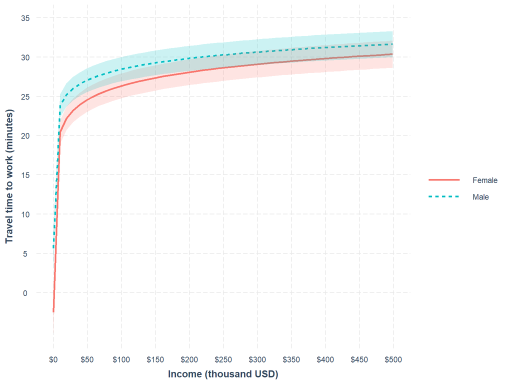

```r
interact_plot(model4, pred = Income, modx = Sex_label, interval = TRUE) +
  scale_x_continuous(name = "Income (thousand USD)",
                     limits = c(0, 500000),
                     breaks = breaks <- seq(0, 500000, by = 50000),
                     labels = paste("$",
                                    prettyNum(breaks/1000, big.mark = "'"),
                                    sep = "")) +
  scale_y_continuous(name = "Travel time to work (minutes)",
                     breaks = seq(0, 45, by = 5)) +
  scale_color_discrete(name = "") +
  scale_linetype_discrete(name = "") +
  scale_fill_discrete(name = "")
```

## Conclusions

For my conclusion, I will visualize the results to compare the variation of the Multiple R-squared value after the adjustments in each model.

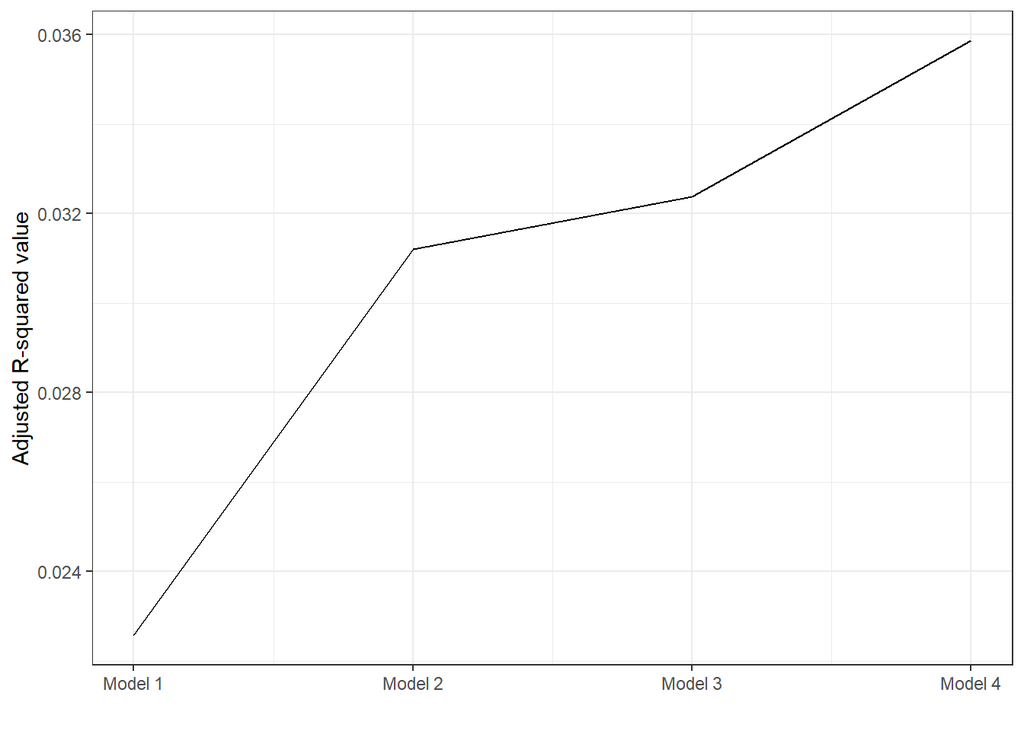

```r
ModelFit <- tibble(model = c(1, 2, 3, 4),
                   R_square = c(summary(model1)$adj.r.squared,
                                summary(model2)$adj.r.squared,
                                summary(model3)$adj.r.squared,
                                summary(model4)$adj.r.squared))

ggplot(ModelFit, aes(x = model, y = R_square)) +
  geom_line() +
  scale_x_continuous(name = "",
                   breaks = breaks <- seq(1, 4, by = 1),
                   labels = paste("Model", breaks)) +
  scale_y_continuous(name = "Adjusted R-squared value") +
  theme_bw()
```

```r
coeff_names <- c("Income" = "Income",
                 "Age" = "Age",
                 "High School Diploma (compared to No schooling completed)" =
                   "Edattain2 Highschool diploma",
                 "College credit (compared to No schooling completed)" = "Edattain3 College credit",
                 "Bachelor degree (compared to No schooling completed)" =
                   "Edattain4 Bachelor",
                 "Masters degree (compared to No schooling completed)" =
                   "Edattain5 Masters",
                 "Doctorate degree (compared to No schooling completed)" =
                   "Edattain6 Doctorate",
                 "Public transportation (compared to private/motor)" =
                    "Meanstransp2 Bus, streetcar or subway",
                 "Active mobility (compared to private/motor)" =
                    "Meanstransp3 Bicycle or walked",
                 "Income (log)" =
                    "log(Income)",
                 "Age 20-65 (compared to <20)" =
                    "Agecat2 Over20 Under65",
                 "Age >65 (compared to <20)" =
                    "Agecat3 Over 65",
                 "Male (compared to female)" =
                    "Sex_labelMale",
                 "Interaction: log(Income) and male" =
                 "log(Income):Sex_labelMale"
                 )

export_summs(model1, model4,
             error_format = "(p = {p.value})",
             error_pos = "same",
             model.names = c("Initial model", "Preferred model"),
             coefs = coeff_names)
```

|  | Initial model | Preferred model |
| --- | --- | --- |
| Income | 0.00 *** (p = 0.00) |  |
| Age | 0.04 *** (p = 0.00) |  |
| High School Diploma (compared to No schooling completed) | -1.49 ** (p = 0.01) | -1.63 ** (p = 0.00) |
| College credit (compared to No schooling completed) | -1.60 ** (p = 0.00) | -1.83 ** (p = 0.00) |
| Bachelor degree (compared to No schooling completed) | -1.93 *** (p = 0.00) | -2.79 *** (p = 0.00) |
| Masters degree (compared to No schooling completed) | -1.95 *** (p = 0.00) | -2.89 *** (p = 0.00) |
| Doctorate degree (compared to No schooling completed) | -3.93 *** (p = 0.00) | -4.88 *** (p = 0.00) |
| Public transportation (compared to private/motor) | 20.66 *** (p = 0.00) | 21.18 *** (p = 0.00) |
| Active mobility (compared to private/motor) | -12.32 *** (p = 0.00) | -11.08 *** (p = 0.00) |
| Income (log) |  | 2.51 *** (p = 0.00) |
| Age 20-65 (compared to <20) |  | 3.60 *** (p = 0.00) |
| Age >65 (compared to <20) |  | 1.23 * (p = 0.05) |
| Male (compared to female) |  | 8.14 *** (p = 0.00) |
| Interaction: log(Income) and male |  | -0.52 *** (p = 0.00) |
| N | 77707 | 77707 |
| R2 | 0.02 | 0.04 |
| *** p < 0.001; ** p < 0.01; * p < 0.05. |  |  |

In general, I consider my Multiple R-Squared value low, but I recognize that travel time is not an easy variable to predict based on my independent variables. Furthermore, considering that my data does not include spatial information such as commuting distances or specific geolocations. However, it is interesting to see how the model fit improves and I can explain better my dependent variable by incorporating new adjustments and layers of analysis into my data set.